# Nanual_exercise5

```python
# Importing necessary packages and assigning user-defined names for them
import pandas as pd
import numpy as np
import matplotlib.pyplot as plt
```

```python
# Importing the 'bank_marketing_training' data set
bank_train = pd.read_csv("C:/Users/Default.DESKTOP-7BESS1K/Desktop/bank_marketing_training")
bank_train
```

|  | age | job | marital | education | default | housing | loan | contact | month | day_of_week | ... | campaign | days_since_previous | previous | previous_outcome | emp.var.rate | cons.price.idx | cons.conf.idx | euribor3m | nr.employed | response |
| --- | --- | --- | --- | --- | --- | --- | --- | --- | --- | --- | --- | --- | --- | --- | --- | --- | --- | --- | --- | --- | --- |
| 0 | 56 | housemaid | married | basic.4y | no | no | no | telephone | may | mon | ... | 1 | 999 | 0 | nonexistent | 1.1 | 93.994 | -36.4 | 4.857 | 5191 | no |
| 1 | 57 | services | married | high.school | unknown | no | no | telephone | may | mon | ... | 1 | 999 | 0 | nonexistent | 1.1 | 93.994 | -36.4 | 4.857 | 5191 | no |
| 2 | 41 | blue-collar | married | unknown | unknown | no | no | telephone | may | mon | ... | 1 | 999 | 0 | nonexistent | 1.1 | 93.994 | -36.4 | 4.857 | 5191 | no |
| 3 | 25 | services | single | high.school | no | yes | no | telephone | may | mon | ... | 1 | 999 | 0 | nonexistent | 1.1 | 93.994 | -36.4 | 4.857 | 5191 | no |
| 4 | 29 | blue-collar | single | high.school | no | no | yes | telephone | may | mon | ... | 1 | 999 | 0 | nonexistent | 1.1 | 93.994 | -36.4 | 4.857 | 5191 | no |
| ... | ... | ... | ... | ... | ... | ... | ... | ... | ... | ... | ... | ... | ... | ... | ... | ... | ... | ... | ... | ... | ... |
| 26869 | 36 | admin. | married | university.degree | no | no | no | cellular | nov | fri | ... | 2 | 999 | 0 | nonexistent | -1.1 | 94.767 | -50.8 | 1.028 | 4963 | no |
| 26870 | 37 | admin. | married | university.degree | no | yes | no | cellular | nov | fri | ... | 1 | 999 | 0 | nonexistent | -1.1 | 94.767 | -50.8 | 1.028 | 4963 | yes |
| 26871 | 29 | unemployed | single | basic.4y | no | yes | no | cellular | nov | fri | ... | 1 | 9 | 1 | success | -1.1 | 94.767 | -50.8 | 1.028 | 4963 | no |
| 26872 | 73 | retired | married | professional.course | no | yes | no | cellular | nov | fri | ... | 1 | 999 | 0 | nonexistent | -1.1 | 94.767 | -50.8 | 1.028 | 4963 | yes |
| 26873 | 46 | blue-collar | married | professional.course | no | no | no | cellular | nov | fri | ... | 1 | 999 | 0 | nonexistent | -1.1 | 94.767 | -50.8 | 1.028 | 4963 | no |

26874 rows × 21 columns

1.) Produce the following graphs. What is the strength of each graph? Weakness? a. Bar graph of marital. b. Bar graph of marital, with overlay of response. c. Normalized bar graph of marital, with overlay of response.

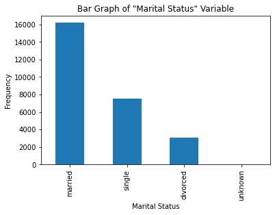

```python
# 1-A. Bar graph of the 'marital' variable
bank_train['marital'].value_counts().plot(kind='bar', stacked=True)
plt.title('Bar Graph of "Marital Status" Variable')
plt.xlabel('Marital Status');
plt.ylabel('Frequency');

# Strength: Fairly straightfoward in presenting data. Thus, it is easily interpreted by the analyst.
# Weakness: Possibly only useable when presenting a limited number of variables.
```

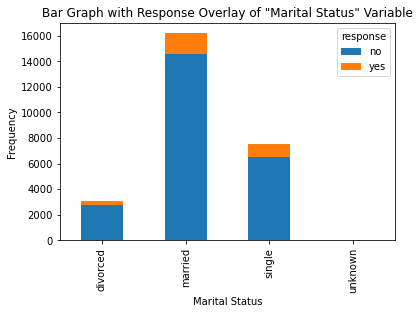

```python
# 1-B. Bar graph of the 'marital' variable with overlay response
tab = pd.crosstab(bank_train['marital'], bank_train['response'])
tab.plot(kind='bar', stacked=True)
plt.title('Bar Graph with Response Overlay of "Marital Status" Variable')
plt.xlabel('Marital Status');
plt.ylabel('Frequency');

# Strength: Perfect for showing the discrepancy in the values between two variables.
# Weakness: The "stacked" format may come off as confusing at first, especially to non-data analysts.
```

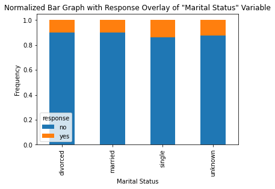

```python
# 1-C. Normalized bar graph of the 'marital' variable with overlay response.
normtab = tab.div(tab.sum(1), axis=0)
normtab.plot(kind='bar', stacked=True)
plt.title('Normalized Bar Graph with Response Overlay of "Marital Status" Variable')
plt.xlabel('Marital Status');
plt.ylabel('Frequency');

# Strength: The presentation of data values is proportioned, so the analyst can easily identify
#           significant differences when comparing two categories.
# Weakness: The "stacked" format may come off as confusing at first, especially to non-data analysts.
```

2. Do the following with the variables marital and response. a. Build a contingency table, being careful to have the correct variables representing the rows and columns. b. Report the counts and the column percentages. c. Describe what the contingency table is telling you.

```python
# 2-A. Contingency table based on the 'marital' and 'response' variables.
tab_2 = pd.crosstab(bank_train['marital'], bank_train['response'])
tab_2
```

| response marital | no | yes |
| --- | --- | --- |
| divorced | 2743 | 312 |
| married | 14579 | 1608 |
| single | 6514 | 1061 |
| unknown | 50 | 7 |

```python
# 2-B. Contingency table with counts and column percentages.
total_2 = tab_2['no'] + tab_2['yes']
tab_2_no = round(((tab_2['no'] / total_2) * 100), 2).astype(str) + '%'
tab_2_yes = round(((tab_2['yes'] / total_2) * 100), 2).astype(str) + '%'
tab_2.insert(1, 'no (in percent)', tab_2_no)
tab_2.insert(3, 'yes (in percent)', tab_2_yes)
tab_2
```

| response marital | no | no (in percent) | yes | yes (in percent) |
| --- | --- | --- | --- | --- |
| divorced | 2743 | 89.79% | 312 | 10.21% |
| married | 14579 | 90.07% | 1608 | 9.93% |
| single | 6514 | 85.99% | 1061 | 14.01% |
| unknown | 50 | 87.72% | 7 | 12.28% |